# Preliminary report for WP3: tail-dependent spatial synchrony among birds

Shyamolina

14 June, 2023

# 1 Intro

[figure not shown]

Figure 1.1: Conceptual figure (will update later)

# 2 Results

## 2.1 r=0-250km

[figure not shown]

Figure 2.1: Spatial synchrony among metapopulation abundance (1997-2019; r=0-250 Km) (A) for species those are synchronously rare, (B) for species those are synchronously abundant. Numeric codes in gray color are unique code for each species (see given csv file for details).

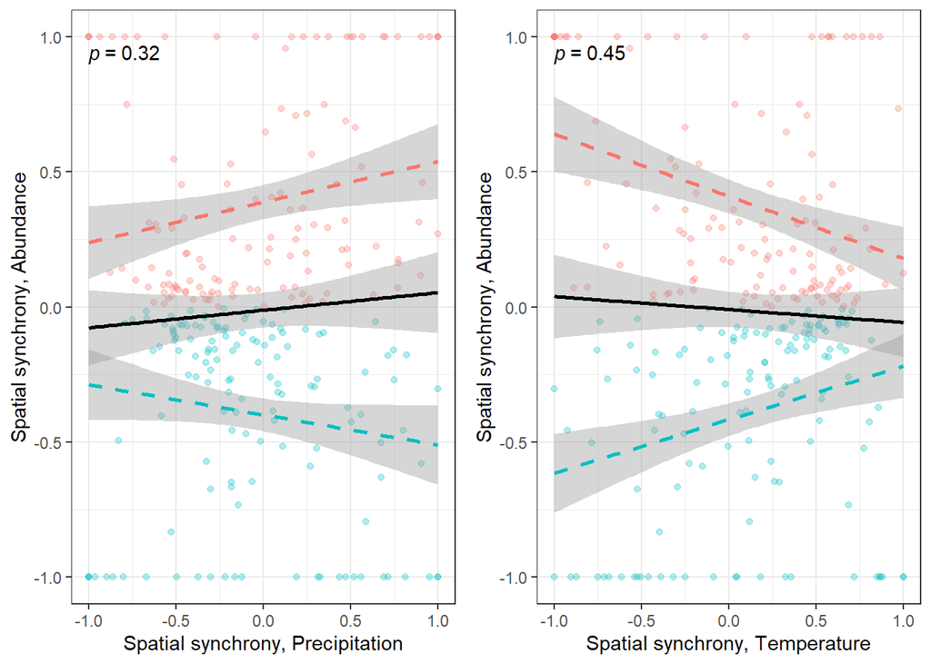

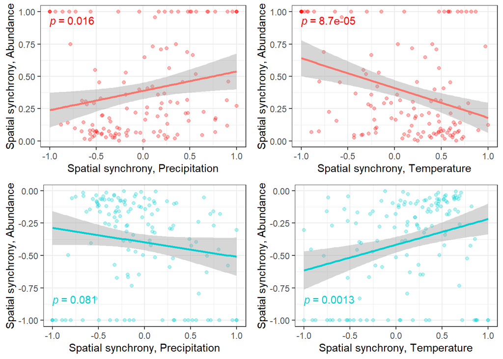

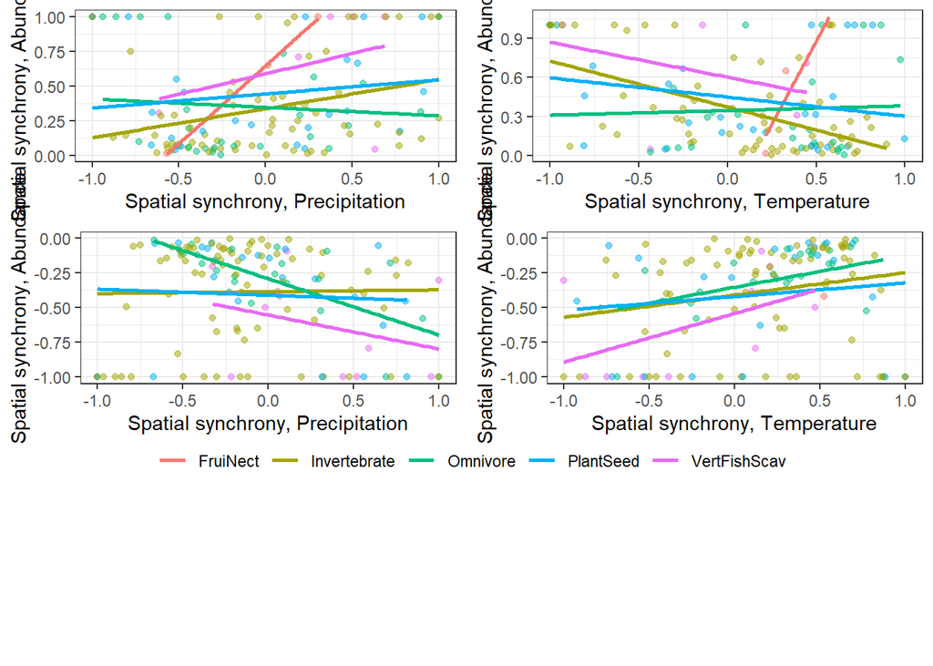

### 2.1.1 Testing body-traits for both red and blue group of birds

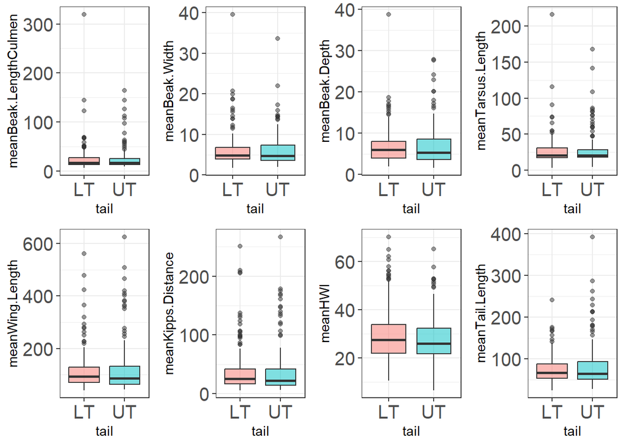

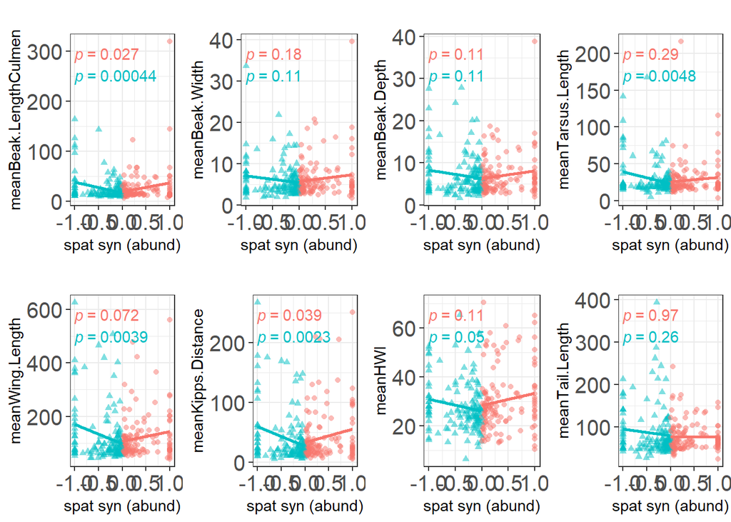

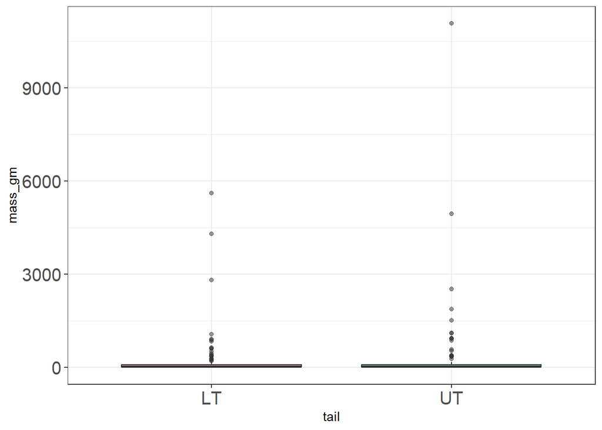

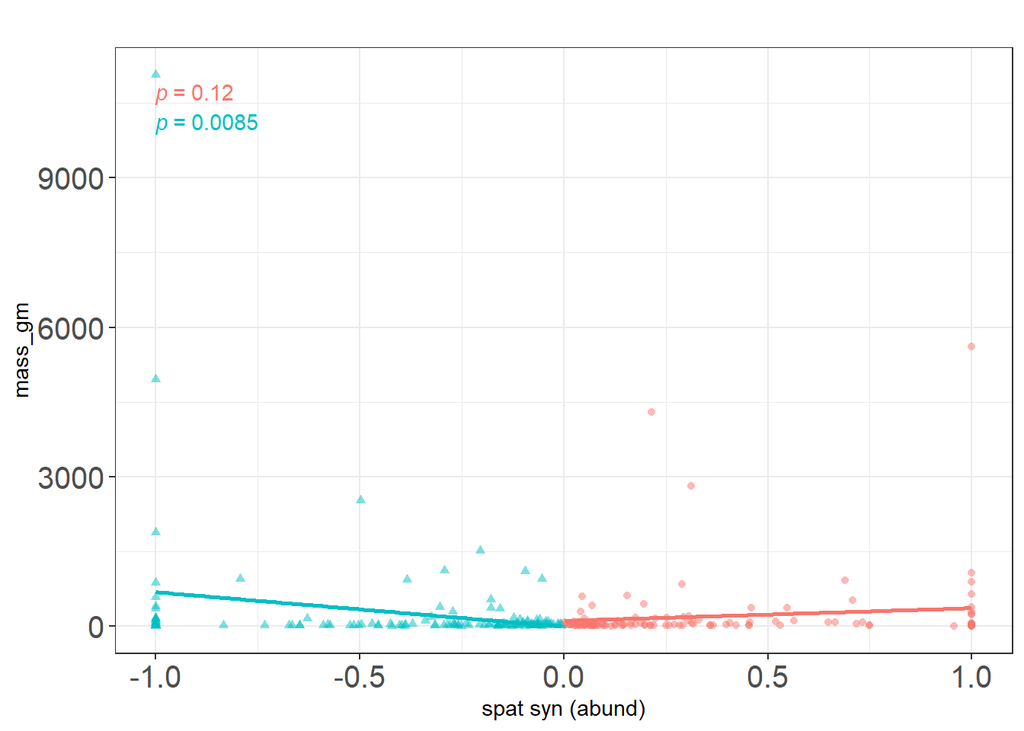

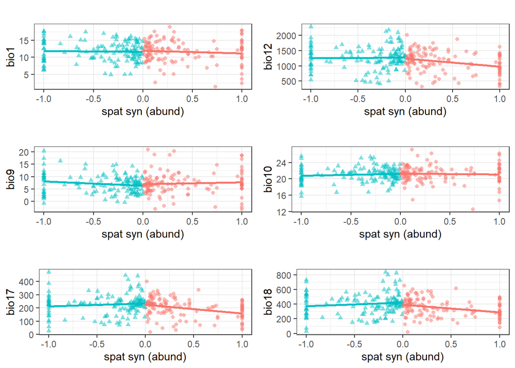

**bio1=** mean annual air temperature (degree C), mean annual daily mean air temperatures averaged over 1 year.

**bio12=** annual precipitation amount (Kg m$^{-2}$ per year), Accumulated precipitation amount over 1 year.

**bio9=** mean daily mean air temperatures of the driest quarter (degree C), The driest quarter of the year is determined (to the nearest month).

**bio10=** mean daily mean air temperatures of the warmest quarter (degree C), The warmest quarter of the year is determined (to the nearest month).

**bio17=** mean monthly precipitation amount of the driest quarter (Kg m$^{-2}$ per month), The driest quarter of the year is determined (to the nearest month).

**bio18=** mean monthly precipitation amount of the warmest quarter (Kg m$^{-2}$ per month), The warmest quarter of the year is determined (to the nearest month).

[figure not shown]

Figure 2.2: Spatial synchrony vs. distance category plot.

**But** to me the species appeared differently in two groups: some species were synchronously rare across metapopulation sites, and some were synchronously common. I think the first group of species were limited by some climatic stressors whereas the second group got the benefit. So, why not consider the dataset separately for each group?